# Final Project Document

# Modeling PR.Status

## Modeling with KNN (predict PR.Status)

First, we will use KNN model to predict `PR.Status`. We will use a test train split of 25/75. We will only be using the non-categorical variables to build the KNN model since we ran into a lot of errors trying to incorporate the categorical variables

We will find the optimal k-value to use, ranging from k=1-10:

```r
library(caret)
library(class)

# set the seed to make partition reproducible
set.seed(432)

k_vals = c(1:10)
err_vals = rep(NA, length(k_vals))

## 75% of the sample size
smp_size <- floor(0.75 * nrow(non_categorical_brca))

for(i in 1:length(k_vals)) {

  train_ind <- sample(seq_len(nrow(non_categorical_brca)), size = smp_size)

  brca_train <- as.matrix(non_categorical_brca[train_ind, ])
  y = as.matrix(predictors$PR.Status[train_ind])

  brca_test <- as.matrix(non_categorical_brca[-train_ind, ])

  pred = knn(train = brca_train, test = brca_test, cl = y, k = i)
  cmat = table(pred, as.factor(predictors$PR.Status[-train_ind]))
  # calculate misclassification rate
  err_vals[i] = (cmat[1,2]+cmat[2,1])/sum(cmat)
}
```

Next, we will plot the graph of the classification errors for each k-value and see if we can use the result to determine the best k:

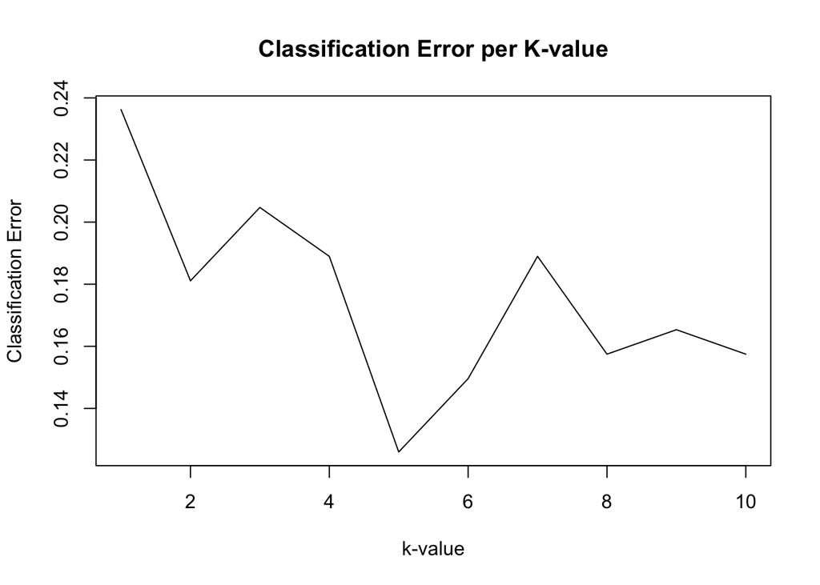

```r
plot(k_vals, err_vals, type = "l", xlab = "k-value", ylab = "Classification Error")
title("Classification Error per K-value")
```

As shown from the plot, the k-value with the lowest classification error is k=5, so we will use that for our model.

Next, use K=5 to create our KNN model and display the confusion matrix:

```r
set.seed(432)
train_y = as.matrix(predictors$PR.Status[train_ind])
y = as.matrix(predictors$PR.Status[train_ind])
pred = knn(train = brca_train, test = brca_test, cl = y, k = 5)
cmat = table(pred, as.factor(predictors$PR.Status[-train_ind]))
cmat
```

```
##
## pred       Negative Positive
##   Negative       31        5
##   Positive       17       74
```

Displaying the accuracy:

```r
(cmat[1,1]+cmat[2,2])/sum(cmat)
```

```
## [1] 0.8267717
```

The classificaton error for a model with k=5 is 1-0.8267717 = 0.1732283.

## Modeling with Lasso (predict PR.Status)

Next, we will create a Lasso model with 10-fold cross-validation to help create `PR.Status`:

```r
suppressMessages(library(glmnet))
set.seed(432)

lasso.fit = cv.glmnet(brca_train, train_y, nfolds = 10, alpha = 1, type.measure = "class", family = "binomial")
```

Plotting the fit of our Lasso model:

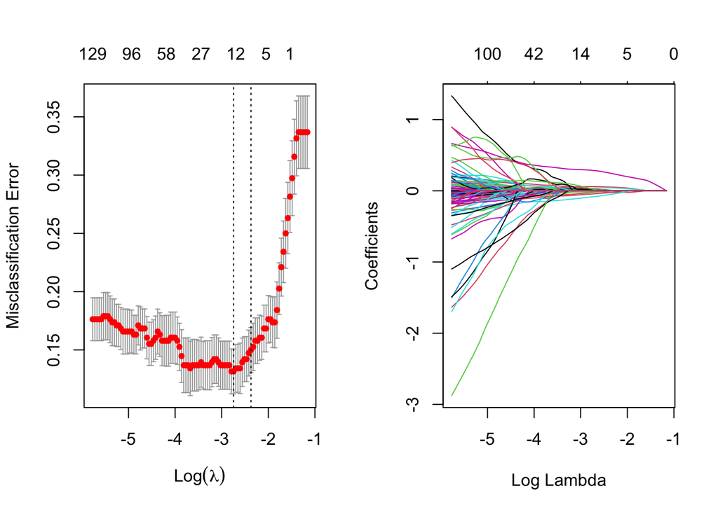

```r
par(mfrow = c(1, 2))
    plot(lasso.fit)
    plot(lasso.fit$glmnet.fit, "lambda")
```

We will use the `best_lambda` to use for the prediction on the test data:

```r
best_lambda = lasso.fit$lambda.min
test_predict = predict(lasso.fit, brca_test, s = best_lambda, type = "class")
```

Displaying the confusion matrix of the results:

```r
cmat_1 = table(predictors$PR.Status[-train_ind], test_predict)
cmat_1
```

```
##           test_predict
##            Negative Positive
##   Negative       32       16
##   Positive        3       76
```

Displaying the accuracy:

```r
(cmat_1[1,1]+cmat_1[2,2])/sum(cmat_1)
```

```
## [1] 0.8503937
```

The classification error is 1-0.8503937 = 0.1496063.

# Modelling `histological.type`

## Modelling `histological.type` with SVM

```r
# SVM, histological type
library(ROCR)
library(e1071)
library(caret)

brca_data = read.csv("https://raw.githubusercontent.com/mgarbvs/STAT-432-final-project/main/cleaned_brca_data.csv")
# remove X.1 and X columns
brca_data = brca_data %>% select(-c("X.1", "X"))
non_response_brca <- brca_data[,-c(which(colnames(brca_data) %in% c('PR.Status','ER.Status','HER2.Final.Status','histological.type')))]

set.seed(432)

#SVM WITH MATCORR DATA

# use correlation matrix
cor_mat = cor(non_response_brca)

# returns vector of indices to remove
cor_list = findCorrelation(cor_mat, cutoff = .7)

non_response_brca <- non_response_brca[,cor_list]

#New BRCA data

train = brca_data$histological.type
train_data_unsplit = cbind(train,non_response_brca)
#continue to use the combined 10 data? or use the full data

#train_data_unsplit[,'train']  1 and 2
#80 20 split
train_rows <- sample(nrow(train_data_unsplit), size = floor(0.8 *nrow(train_data_unsplit)))
train_data <- train_data_unsplit[train_rows,]
test_data = train_data_unsplit[-train_rows,]

#Let's consider a few different kernels
#Sigma is the distance from the boundary
#Do we want a high cost? Or a low one?

svm.radial <- train(train ~ ., data = train_data, method = "svmRadial",
                preProcess = c("center", "scale"),
                tuneGrid = expand.grid(C = c(0.01, 0.1, 0.5, 1), sigma = c(1, 2, 3)),
                trControl = trainControl(method = "cv", number = 5))


svm.linear <- train(train ~ ., data = train_data, method = 'svmLinear',
                preProcess = c("center", "scale"),
                tuneGrid = expand.grid(C = c(0.01, 0.1, 0.5, 1)),
                trControl = trainControl(method = "cv", number = 5))
```

Let us display the SVM results for radial and linear models respectively:

```r
svm.radial
```

```
## Support Vector Machines with Radial Basis Function Kernel
##
## 405 samples
## 979 predictors
##   2 classes: 'infiltrating ductal carcinoma', 'infiltrating lobular carcinoma'
##
## Pre-processing: centered (979), scaled (979)
## Resampling: Cross-Validated (5 fold)
## Summary of sample sizes: 324, 325, 324, 323, 324
## Resampling results across tuning parameters:
##
##   C     sigma  Accuracy   Kappa
##   0.01  1      0.9037285  0
##   0.01  2      0.9037285  0
##   0.01  3      0.9037285  0
##   0.10  1      0.9037285  0
##   0.10  2      0.9037285  0
##   0.10  3      0.9037285  0
##   0.50  1      0.9037285  0
##   0.50  2      0.9037285  0
##   0.50  3      0.9037285  0
##   1.00  1      0.9037285  0
##   1.00  2      0.9037285  0
##   1.00  3      0.9037285  0
##
## Accuracy was used to select the optimal model using the largest value.
## The final values used for the model were sigma = 3 and C = 0.01.
```

```r
svm.linear
```

```
## Support Vector Machines with Linear Kernel
##
## 405 samples
## 979 predictors
##   2 classes: 'infiltrating ductal carcinoma', 'infiltrating lobular carcinoma'
##
## Pre-processing: centered (979), scaled (979)
## Resampling: Cross-Validated (5 fold)
## Summary of sample sizes: 325, 323, 324, 324, 324
## Resampling results across tuning parameters:
##
##   C     Accuracy   Kappa
##   0.01  0.9234831  0.5484948
##   0.10  0.8840334  0.3695863
##   0.50  0.8840334  0.3695863
##   1.00  0.8840334  0.3695863
##
## Accuracy was used to select the optimal model using the largest value.
## The final value used for the model was C = 0.01.
```

Next, we will use each model to predict on the test data:

```r
suppressMessages(library(kableExtra))
linear_svm_prediction <- predict(svm.linear, test_data[,-1])

radial_svm_prediction <- predict(svm.radial, test_data[,-1])

#Radial --> unable to classify any infiltrating lobular carcinoma. Linear is the better model
suppressMessages(library(ROCR))

lin.svm <- prediction(as.numeric(as.factor(linear_svm_prediction)), as.factor(test_data[,1]))

rad.svm <- prediction(as.numeric(as.factor(radial_svm_prediction)), as.factor(test_data[,1]))
```

Finally, let us display the results of the Linear and Radial SVM AUC:

```r
# Linear has a performance of about 65.98%
performance(lin.svm,measure = "auc")@y.values[[1]]
```

```
## [1] 0.6598402
```

```r
# Radial has performance of about 50%
performance(rad.svm,measure = "auc")@y.values[[1]]
```

```
## [1] 0.5
```

Looking at the results above, Linear SVM has AUC = 0.6598402 and Radial SVM has AUC = 0.5. We can conclude that Linear SVM is probably the better model due to this significant difference.

## Modelling `histological.type` with Random Forests

Next, let us use a Random Forest model:

```r
train_y_hist= as.matrix(predictors$histological.type[train_ind])
brca_train_2 = as.matrix(cbind(brca_train, train_y_hist))
```

Let us fit the model with `nodesize=8` and `sampsize=50`. Through multiple rounds of experimentation with values, we found those parameters to be most optimal:

```r
suppressMessages(library(randomForest))
set.seed(432)
rf.fit = randomForest(data.matrix(brca_train_2[, -c(640)]), y = as.factor(brca_train_2[, 640]), ntree = 4, mtry = 4, nodesize = 8, sampsize = 50)
```

Next, use this model to predict on the test data:

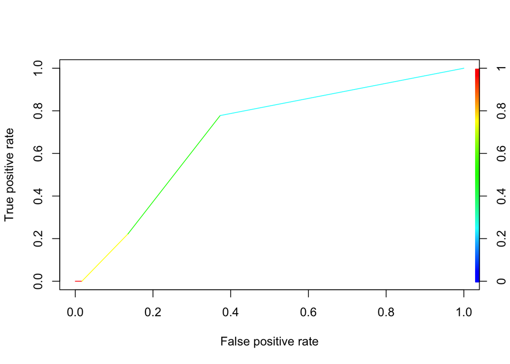

```r
test.predictions <- predict(rf.fit, type="prob", newdata=brca_test)[,2]

correct_hist = as.factor(predictors$histological.type[-train_ind])
rf_pr_test <- prediction(test.predictions, correct_hist)
r_auc_test <- performance(rf_pr_test, "tpr","fpr")
plot(r_auc_test, colorize=TRUE)
```

The AUC:

```r
performance(rf_pr_test, measure = "auc")@y.values[[1]]
```

```
## [1] 0.6892655
```

### `histological.type` Summary:

To summarize our models, we used Linear and Radial SVM, with had AUC values of 0.6598402 and 0.5 respectively. For random forest, the AUC value resulted in 0.6892655. Therefore, the random forest model can be determined as the better model, although its AUC score is still a bit low.

# 50-Variable Selection

## PR.Status

```r
library(dplyr)
brca_data = read.csv("https://raw.githubusercontent.com/mgarbvs/STAT-432-final-project/main/cleaned_brca_data.csv")
# remove X.1 and X columns
brca_data = brca_data %>% select(-c("X.1", "X"))

# store the outcomes
outcomes = brca_data %>% select(c("PR.Status", "ER.Status", "HER2.Final.Status", "histological.type"))
# remove the categorical var temporarily
brca_data = brca_data %>% select(-c("PR.Status", "ER.Status", "HER2.Final.Status", "histological.type"))

# Create a correlation matrix and select only variables with some correlation to the target
PR.Status = as.numeric(as.factor(outcomes$PR.Status))-1
pr_data = cbind(PR.Status, brca_data)

pr_data[sapply(pr_data, is.character)] <- lapply(pr_data[sapply(pr_data, is.character)], as.numeric)


# head(pr_data)

M <- cor(pr_data)
correlation_threshold <- 0.446
significant_correlation <- abs(M["PR.Status", ]) > correlation_threshold
table(significant_correlation)
```

```
## significant_correlation
## FALSE  TRUE
##  1886    51
```

```r
corr_colnames <- colnames(M)[significant_correlation]
```

```r
suppressMessages(library(caret))
# Linear regression model with selected features, 10 K-fold cross validation using the "caret" package --------------
set.seed(432)

## 75% of the sample size
smp_size <- floor(0.75 * nrow(pr_data))

## set the seed to make your partition reproducible
train_ind <- sample(seq_len(nrow(pr_data)), size = smp_size)

train_y <- outcomes$PR.Status[train_ind]
pr_train <- cbind(train_y, pr_data[train_ind, ])
pr_train <- pr_train[, corr_colnames]

# Training parameters
ctrl <- trainControl(method = "cv",
                     number = 5,
                     savePredictions = TRUE,
                     classProbs = FALSE)

# Fitting model
mod_fit <- train(as.factor(PR.Status) ~ ., data=pr_train,
                 method="glm",
                 family="binomial",
                 trControl = ctrl,
                 tuneLength = 5)
```

```r
summary(mod_fit)
```

```
##
## Call:
## NULL
##
## Deviance Residuals:
##     Min       1Q   Median       3Q      Max
## -3.2824  -0.1375   0.0672   0.2986   2.3869
##
## Coefficients:
##                Estimate Std. Error z value Pr(>|z|)
## (Intercept)   2.239e+00  3.857e+00   0.581 0.561543
## rs_TFF1      -1.483e-02  1.374e-01  -0.108 0.914037
## rs_CYP2B7P1   2.265e-01  9.449e-02   2.397 0.016525 *
## rs_AGR3       1.365e-01  1.512e-01   0.903 0.366535
## rs_C1orf64   -3.771e-01  1.530e-01  -2.466 0.013673 *
## rs_TFF3       5.694e-02  1.757e-01   0.324 0.745846
## rs_AGR2       1.182e-01  1.681e-01   0.703 0.481818
## rs_GFRA1      1.312e-01  1.096e-01   1.198 0.231024
## rs_PGR        6.742e-01  1.966e-01   3.430 0.000604 ***
## rs_VGLL1     -7.153e-02  1.480e-01  -0.483 0.628819
## rs_SERPINA11  2.004e-02  1.278e-01   0.157 0.875348
## rs_A2ML1     -2.156e-01  1.068e-01  -2.019 0.043456 *
## rs_PTPRT      1.076e-01  1.173e-01   0.917 0.359118
## rs_ESR1      -6.531e-01  2.918e-01  -2.238 0.025204 *
## rs_SYT9      -8.222e-03  1.070e-01  -0.077 0.938773
## rs_GRPR       2.118e-01  1.363e-01   1.554 0.120260
## rs_CHAD      -6.777e-02  1.121e-01  -0.604 0.545638
## rs_ABCC8     -2.369e-01  1.317e-01  -1.799 0.072056 .
## rs_PGLYRP2    9.117e-02  1.115e-01   0.817 0.413644
## rs_SCUBE2    -1.256e-01  1.867e-01  -0.673 0.501028
## rs_NEK10     -6.247e-02  1.636e-01  -0.382 0.702546
## rs_ERBB4     -1.088e-01  1.596e-01  -0.682 0.495434
## rs_FSIP1      4.746e-02  1.781e-01   0.266 0.789873
## rs_FOXA1     -2.325e-01  2.695e-01  -0.863 0.388207
## rs_NAT1       2.792e-01  1.454e-01   1.920 0.054814 .
## rs_SLC7A2    -4.151e-01  1.519e-01  -2.733 0.006271 **
## rs_FLJ45983   2.114e-01  1.541e-01   1.372 0.170134
## rs_ART3       1.355e-01  1.470e-01   0.922 0.356721
## rs_PPP1R14C  -1.188e-01  1.730e-01  -0.687 0.492117
## rs_RGS22     -5.212e-03  1.463e-01  -0.036 0.971592
```

[output cut: 16 more lines]

```
## cn_EDIL3      1.368e+01  1.385e+03   0.010 0.992123
## pp_ASNS      -2.633e-01  5.098e-01  -0.516 0.605516
## pp_ER.alpha   5.648e-01  3.039e-01   1.859 0.063096 .
## pp_GATA3     -1.914e-01  3.922e-01  -0.488 0.625517
## pp_PR         1.195e-01  2.478e-01   0.482 0.629684
## ---
## Signif. codes:  0 '***' 0.001 '**' 0.01 '*' 0.05 '.' 0.1 ' ' 1
##
## (Dispersion parameter for binomial family taken to be 1)
##
##     Null deviance: 485.58  on 379  degrees of freedom
## Residual deviance: 169.42  on 329  degrees of freedom
## AIC: 271.42
##
## Number of Fisher Scoring iterations: 15
```

Compute and plot the AUC:

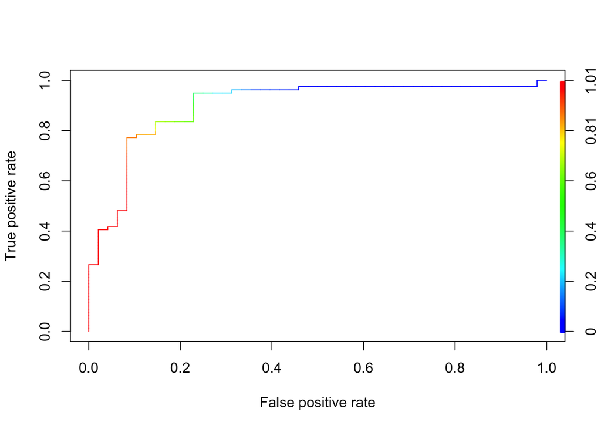

```r
test_y <- outcomes$PR.Status[-train_ind]
pr_test <- cbind(test_y, pr_data[-train_ind, ])

# length(test_y)
# dim(pr_data[-train_ind,])

test_predict <- predict(mod_fit, pr_test, type="prob")
roc <- prediction(test_predict[,2], test_y)

# calculates the ROC curve
perf <- performance(roc,"tpr","fpr")
plot(perf,colorize=TRUE)
```

```r
# obtaining the AUC
performance(roc, measure = "auc")@y.values[[1]]
```

```
## [1] 0.8989979
```

The AUC for PR.Status is 0.8989979.

## Histological.Type

```r
library(dplyr)
brca_data = read.csv("https://raw.githubusercontent.com/mgarbvs/STAT-432-final-project/main/cleaned_brca_data.csv")
# remove X.1 and X columns
brca_data = brca_data %>% select(-c("X.1", "X"))

# store the outcomes
outcomes = brca_data %>% select(c("PR.Status", "ER.Status", "HER2.Final.Status", "histological.type"))
# remove the categorical var temporarily
brca_data = brca_data %>% select(-c("PR.Status", "ER.Status", "HER2.Final.Status", "histological.type"))

# Create a correlation matrix and select only variables with some correlation to the target
histological.type = as.numeric(as.factor(outcomes$histological.type))

hist_data = cbind(histological.type, brca_data)

# head(hist_data,20)

hist_data[sapply(hist_data, is.character)] <- lapply(hist_data[sapply(hist_data, is.character)], as.numeric)
```

```r
M <- cor(hist_data)
correlation_threshold <- 0.204
significant_correlation <- abs(M["histological.type", ]) > correlation_threshold
table(significant_correlation)
```

```
## significant_correlation
## FALSE  TRUE
##  1886    51
```

```r
corr_colnames <- colnames(M)[significant_correlation]
```

```r
library(caret)

set.seed(432)

## 75% of the sample size
smp_size <- floor(0.75 * nrow(hist_data))

## set the seed to make your partition reproducible
train_ind <- sample(seq_len(nrow(hist_data)), size = smp_size)


train_y <- outcomes$histological.type[train_ind]
hist_train <- cbind(train_y, hist_data[train_ind, ])
hist_train <- hist_train[, corr_colnames]


# Training parameters
ctrl <- trainControl(method = "cv",
                     number = 5,
                     savePredictions = TRUE,
                     classProbs = FALSE)

# Fitting model
mod_fit <- train(as.factor(histological.type) ~ ., data=hist_train,
                 method="glm",
                 family="binomial",
                 trControl = ctrl,
                 tuneLength = 5)
```

```r
summary(mod_fit)
```

```
##
## Call:
## NULL
##
## Deviance Residuals:
##      Min        1Q    Median        3Q       Max
## -2.07602  -0.06594  -0.01469  -0.00141   2.54704
##
## Coefficients:
##                   Estimate Std. Error z value Pr(>|z|)
## (Intercept)     -1.476e+01  4.948e+00  -2.984 0.002849 **
## rs_TFAP2B        1.662e-01  1.896e-01   0.877 0.380744
## rs_CYP4Z1       -3.451e-02  1.778e-01  -0.194 0.846115
## rs_C7           -1.996e-01  4.106e-01  -0.486 0.626864
## rs_ABCA8         2.879e-01  4.696e-01   0.613 0.539849
## rs_SLC26A3       2.155e-01  1.744e-01   1.235 0.216705
## rs_ADCY5        -5.141e-02  2.788e-01  -0.184 0.853714
## rs_RERGL         7.007e-01  4.343e-01   1.613 0.106642
## rs_ANKRD43       3.110e-01  2.359e-01   1.318 0.187410
## rs_LOC389033    -1.143e-01  2.593e-01  -0.441 0.659404
## rs_CCL14        -9.174e-02  6.062e-01  -0.151 0.879725
## rs_MMRN1         2.245e-01  3.218e-01   0.698 0.485381
## cn_PART1        -1.521e-01  2.783e+00  -0.055 0.956405
## cn_GTF2H2B      -8.524e-01  1.114e+01  -0.076 0.939026
## cn_CARTPT       -2.972e+00  2.154e+01  -0.138 0.890265
## cn_FOXD1         5.581e+00  2.161e+01   0.258 0.796189
## cn_F2RL2         2.366e+01  8.390e+03   0.003 0.997750
## cn_PDE8B        -2.296e+01  8.390e+03  -0.003 0.997816
## cn_THBS4         1.689e+01  4.711e+03   0.004 0.997139
## cn_CKMT2         7.321e+00  8.693e+03   0.001 0.999328
## cn_HAPLN1       -1.575e+01  1.254e+04  -0.001 0.998998
## cn_EDIL3        -1.154e+01  7.718e+03  -0.001 0.998807
## cn_GPR98        -1.013e+00  1.559e+01  -0.065 0.948220
## cn_FAM81B       -2.754e+00  2.191e+03  -0.001 0.998997
## cn_C5orf27      -3.445e+00  2.313e+03  -0.001 0.998812
## cn_PCSK1         5.015e+00  3.710e+03   0.001 0.998922
## cn_ERAP2         2.211e+00  1.901e+03   0.001 0.999072
## cn_EFNA5         1.214e+00  1.678e+01   0.072 0.942319
## cn_TSLP          1.120e+01  5.599e+03   0.002 0.998403
## cn_TRIM36       -1.126e+01  5.599e+03  -0.002 0.998396
```

[output cut: 16 more lines]

```
## pp_Rab11        -3.036e+00  1.947e+00  -1.559 0.119019
## pp_S6           -1.613e+00  1.307e+00  -1.234 0.217064
## pp_SLC1A5       -7.351e-01  9.635e-01  -0.763 0.445498
## pp_beta.Catenin -4.839e-01  1.378e+00  -0.351 0.725543
## pp_eIF4G        -1.539e+00  1.270e+00  -1.212 0.225454
## ---
## Signif. codes:  0 '***' 0.001 '**' 0.01 '*' 0.05 '.' 0.1 ' ' 1
##
## (Dispersion parameter for binomial family taken to be 1)
##
##     Null deviance: 251.428  on 379  degrees of freedom
## Residual deviance:  59.391  on 329  degrees of freedom
## AIC: 161.39
##
## Number of Fisher Scoring iterations: 19
```

Compute and plot the AUC:

```r
test_y <- as.data.frame(outcomes$histological.type[-train_ind])

dim(test_y)
```

```
## [1] 127   1
```

```r
dim(hist_data[-train_ind,])
```

```
## [1]  127 1937
```

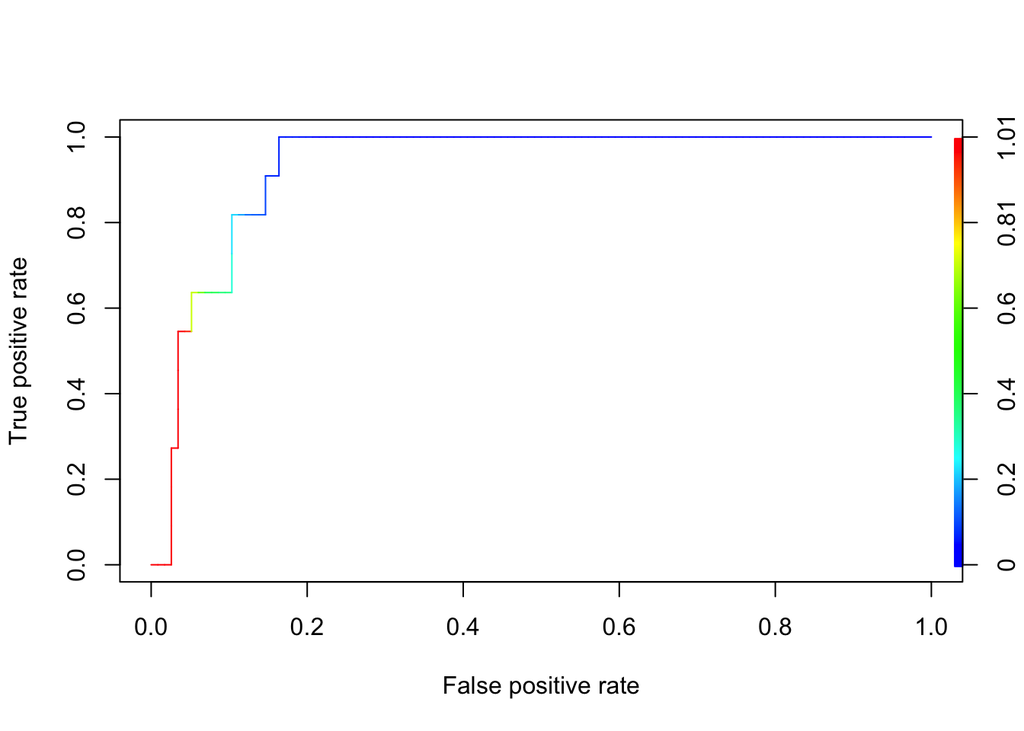

```r
hist_test <- cbind(test_y, hist_data[-train_ind, ])

test_predict <- predict(mod_fit, hist_test, type="prob")
roc <- prediction(test_predict[,2], test_y)

# calculates the ROC curve
perf <- performance(roc,"tpr","fpr")
plot(perf,colorize=TRUE)
```

```r
# obtaining the AUC
performance(roc, measure = "auc")@y.values[[1]]
```

```
## [1] 0.9318182
```

The AUC for histological.type is 0.9318182.

## ER.Status

```r
library(dplyr)
brca_data = read.csv("https://raw.githubusercontent.com/mgarbvs/STAT-432-final-project/main/cleaned_brca_data.csv")
# remove X.1 and X columns
brca_data = brca_data %>% select(-c("X.1", "X"))

# store the outcomes
outcomes = brca_data %>% select(c("PR.Status", "ER.Status", "HER2.Final.Status", "histological.type"))
# remove the categorical var temporarily
brca_data = brca_data %>% select(-c("PR.Status", "ER.Status", "HER2.Final.Status", "histological.type"))

# Create a correlation matrix and select only variables with some correlation to the target
ER.Status = as.numeric(as.factor(outcomes$ER.Status))

er_data = cbind(ER.Status, brca_data)


er_data[sapply(er_data, is.character)] <- lapply(er_data[sapply(er_data, is.character)], as.numeric)
```

```r
M <- cor(er_data)
correlation_threshold <- 0.501
significant_correlation <- abs(M["ER.Status", ]) > correlation_threshold
table(significant_correlation)
```

```
## significant_correlation
## FALSE  TRUE
##  1886    51
```

```r
corr_colnames <- colnames(M)[significant_correlation]
```

```r
library(caret)

set.seed(432)

## 75% of the sample size
smp_size <- floor(0.75 * nrow(er_data))

## set the seed to make your partition reproducible
train_ind <- sample(seq_len(nrow(er_data)), size = smp_size)


train_y <- outcomes$ER.Status[train_ind]
er_train <- cbind(train_y, er_data[train_ind, ])
er_train <- er_train[, corr_colnames]


# Training parameters
ctrl <- trainControl(method = "cv",
                     number = 5,
                     savePredictions = TRUE,
                     classProbs = FALSE)

# Fitting model
mod_fit <- train(as.factor(ER.Status) ~ ., data=er_train,
                 method="glm",
                 family="binomial",
                 trControl = ctrl,
                 tuneLength = 5)
```

```r
summary(mod_fit)
```

```
##
## Call:
## NULL
##
## Deviance Residuals:
##    Min      1Q  Median      3Q     Max
##  -8.49    0.00    0.00    0.00    8.49
##
## Coefficients:
##                Estimate Std. Error    z value Pr(>|z|)
## (Intercept)   6.956e+15  6.099e+07  114052178   <2e-16 ***
## rs_TFF1       3.932e+14  2.018e+06  194897908   <2e-16 ***
## rs_CYP2B7P1   9.201e+13  1.487e+06   61865404   <2e-16 ***
## rs_AGR3       3.333e+14  2.543e+06  131095335   <2e-16 ***
## rs_GP2        1.626e+13  1.546e+06   10515790   <2e-16 ***
## rs_C1orf64   -1.600e+14  2.082e+06  -76861520   <2e-16 ***
## rs_TFF3      -3.281e+14  2.782e+06 -117932448   <2e-16 ***
## rs_AGR2       2.001e+14  2.718e+06   73633411   <2e-16 ***
## rs_GFRA1      5.871e+13  1.768e+06   33202850   <2e-16 ***
## rs_PGR        6.277e+13  2.000e+06   31392302   <2e-16 ***
## rs_VGLL1     -6.556e+13  2.397e+06  -27352502   <2e-16 ***
## rs_SERPINA11 -2.112e+14  1.889e+06 -111825460   <2e-16 ***
## rs_KRT16     -2.747e+14  2.311e+06 -118860169   <2e-16 ***
## rs_A2ML1     -4.880e+13  2.044e+06  -23879318   <2e-16 ***
## rs_ESR1      -7.516e+13  3.914e+06  -19203128   <2e-16 ***
## rs_SYT9      -4.261e+13  1.871e+06  -22777598   <2e-16 ***
## rs_GRPR       1.063e+14  1.890e+06   56220055   <2e-16 ***
## rs_CHAD      -7.531e+13  1.729e+06  -43558352   <2e-16 ***
## rs_WNK4      -5.822e+13  2.182e+06  -26676185   <2e-16 ***
## rs_ABCC8      1.311e+14  2.053e+06   63864341   <2e-16 ***
## rs_SLC44A4    3.206e+14  2.482e+06  129174389   <2e-16 ***
## rs_SCUBE2    -2.141e+14  2.596e+06  -82500887   <2e-16 ***
## rs_ERBB4      8.612e+13  2.375e+06   36257897   <2e-16 ***
## rs_BCAS1      1.337e+14  2.528e+06   52887597   <2e-16 ***
## rs_HORMAD1   -7.558e+13  2.281e+06  -33132008   <2e-16 ***
## rs_FSIP1     -7.670e+13  2.547e+06  -30114803   <2e-16 ***
## rs_FOXA1     -7.239e+14  4.188e+06 -172844038   <2e-16 ***
## rs_NAT1      -1.273e+14  2.235e+06  -56954494   <2e-16 ***
## rs_SLC7A2    -4.000e+13  2.001e+06  -19986653   <2e-16 ***
## rs_FLJ45983  -8.835e+13  2.440e+06  -36211345   <2e-16 ***
```

[output cut: 16 more lines]

```
## rs_ACE2      -1.016e+14  2.300e+06  -44182529   <2e-16 ***
## rs_AMY1A      1.702e+14  2.500e+06   68058773   <2e-16 ***
## pp_ER.alpha   8.526e+14  4.122e+06  206849284   <2e-16 ***
## pp_GATA3     -2.602e+14  6.658e+06  -39080374   <2e-16 ***
## pp_INPP4B    -1.661e+14  5.823e+06  -28519970   <2e-16 ***
## ---
## Signif. codes:  0 '***' 0.001 '**' 0.01 '*' 0.05 '.' 0.1 ' ' 1
##
## (Dispersion parameter for binomial family taken to be 1)
##
##     Null deviance:  411.29  on 379  degrees of freedom
## Residual deviance: 1009.22  on 329  degrees of freedom
## AIC: 1111.2
##
## Number of Fisher Scoring iterations: 25
```

Compute and plot the AUC:

```r
library(pROC)
library(ROCR)

test_y <- as.data.frame(outcomes$ER.Status[-train_ind])

dim(test_y)
```

```
## [1] 127   1
```

```r
dim(er_data[-train_ind,])
```

```
## [1]  127 1937
```

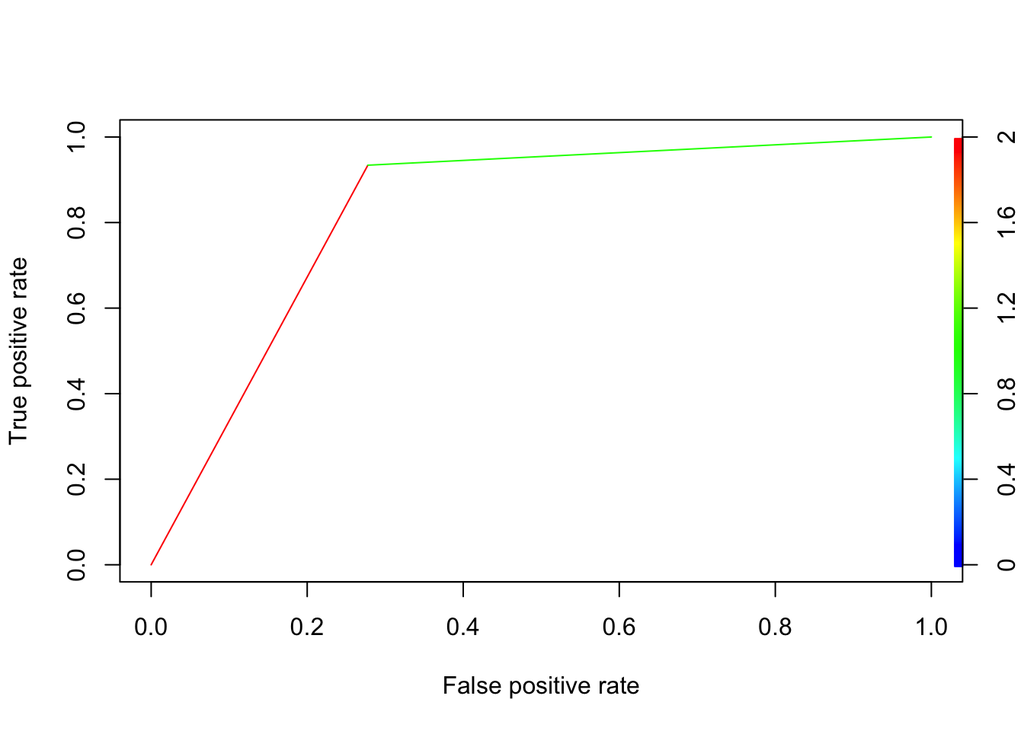

```r
er_test <- cbind(test_y, er_data[-train_ind, ])

test_predict <- predict(mod_fit, er_test, type="prob")
roc <- prediction(test_predict[,2], test_y)

# calculates the ROC curve
perf <- performance(roc,"tpr","fpr")
plot(perf,colorize=TRUE)
```

```r
# obtaining the AUC
performance(roc, measure = "auc")@y.values[[1]]
```

```
## [1] 0.8281441
```

The AUC for ER.Status is 0.8281441.

## HER2.Final.Status

```r
library(dplyr)
brca_data = read.csv("https://raw.githubusercontent.com/mgarbvs/STAT-432-final-project/main/cleaned_brca_data.csv")
# remove X.1 and X columns
brca_data = brca_data %>% select(-c("X.1", "X"))

# store the outcomes
outcomes = brca_data %>% select(c("PR.Status", "ER.Status", "HER2.Final.Status", "histological.type"))
# remove the categorical var temporarily
brca_data = brca_data %>% select(-c("PR.Status", "ER.Status", "HER2.Final.Status", "histological.type"))

# Create a correlation matrix and select only variables with some correlation to the target
HER2.Final.Status = as.numeric(as.factor(outcomes$HER2.Final.Status))

final_status_data = cbind(HER2.Final.Status, brca_data)


final_status_data[sapply(final_status_data, is.character)] <- lapply(final_status_data[sapply(final_status_data, is.character)], as.numeric)
```

```r
M <- cor(final_status_data)
correlation_threshold <- 0.193
significant_correlation <- abs(M["HER2.Final.Status", ]) > correlation_threshold
table(significant_correlation)
```

```
## significant_correlation
## FALSE  TRUE
##  1886    51
```

```r
corr_colnames <- colnames(M)[significant_correlation]
```

```r
library(caret)

set.seed(432)

## 75% of the sample size
smp_size <- floor(0.75 * nrow(final_status_data))

## set the seed to make your partition reproducible
train_ind <- sample(seq_len(nrow(final_status_data)), size = smp_size)


train_y <- outcomes$HER2.Final.Status[train_ind]
final_status_train <- cbind(train_y, final_status_data[train_ind, ])
final_status_train <- final_status_train[, corr_colnames]


# Training parameters
ctrl <- trainControl(method = "cv",
                     number = 5,
                     savePredictions = TRUE,
                     classProbs = FALSE)

# Fitting model
mod_fit <- train(as.factor(HER2.Final.Status) ~ ., data=final_status_train,
                 method="glm",
                 family="binomial",
                 trControl = ctrl,
                 tuneLength = 5)
```

```r
summary(mod_fit)
```

```
##
## Call:
## NULL
##
## Deviance Residuals:
##      Min        1Q    Median        3Q       Max
## -2.24054  -0.00491  -0.00009   0.00000   2.80863
##
## Coefficients: (1 not defined because of singularities)
##                 Estimate Std. Error z value Pr(>|z|)
## (Intercept)    -27.17755   12.04701  -2.256   0.0241 *
## rs_MUCL1         0.22531    0.20470   1.101   0.2710
## rs_CEACAM5       1.29164    0.61157   2.112   0.0347 *
## rs_HOXB13       -0.11247    0.23362  -0.481   0.6302
## rs_CEACAM6      -0.98037    0.49446  -1.983   0.0474 *
## rs_CRISP3       -0.09467    0.25442  -0.372   0.7098
## rs_ABCC11        1.16431    0.63779   1.826   0.0679 .
## rs_GRIA2        -1.05074    0.58815  -1.787   0.0740 .
## rs_NPY1R         0.66636    0.49945   1.334   0.1821
## rs_LRP2          0.04876    0.30879   0.158   0.8745
## rs_KLK10         0.36831    0.32701   1.126   0.2600
## rs_CYP4Z2P      -0.84002    0.48280  -1.740   0.0819 .
## rs_ABCA12        0.01335    0.37746   0.035   0.9718
## rs_SDR16C5       0.04623    0.21389   0.216   0.8289
## rs_C2orf54      -0.61569    0.38931  -1.581   0.1138
## rs_S100A7A      -0.07818    0.49153  -0.159   0.8736
## rs_SLC9A2       -0.01864    0.30032  -0.062   0.9505
## rs_PPP4R4       -0.57069    0.42206  -1.352   0.1763
## rs_PNMT         -0.26830    0.42068  -0.638   0.5236
## rs_PAX7          1.15414    0.54633   2.113   0.0346 *
## rs_C2CD4A       -1.36189    0.60459  -2.253   0.0243 *
## rs_NPY5R        -0.87043    0.51127  -1.702   0.0887 .
## rs_ONECUT2      -0.61152    0.37080  -1.649   0.0991 .
## rs_RBM24        -0.36237    0.39749  -0.912   0.3620
## rs_AKR1B10       0.75353    0.45295   1.664   0.0962 .
## rs_TDRD1         0.56589    0.45432   1.246   0.2129
## rs_IYD           0.74123    0.50757   1.460   0.1442
## rs_PP14571       0.30492    0.36571   0.834   0.4044
## rs_ABCC12       -0.71509    0.53994  -1.324   0.1854
## rs_SCRG1        -1.92828    0.77897  -2.475   0.0133 *
```

[output cut: 16 more lines]

```
## pp_G6PD          0.44436    1.43639   0.309   0.7570
## pp_HER2          3.51959    2.24336   1.569   0.1167
## pp_HER2.pY1248  -2.62099    2.95507  -0.887   0.3751
## pp_HER3.pY1289   3.44563    2.87949   1.197   0.2315
## pp_p70S6K        6.00234    2.47261   2.428   0.0152 *
## ---
## Signif. codes:  0 '***' 0.001 '**' 0.01 '*' 0.05 '.' 0.1 ' ' 1
##
## (Dispersion parameter for binomial family taken to be 1)
##
##     Null deviance: 347.739  on 379  degrees of freedom
## Residual deviance:  57.459  on 330  degrees of freedom
## AIC: 157.46
##
## Number of Fisher Scoring iterations: 15
```

Compute and plot the AUC:

```r
test_y <- as.data.frame(outcomes$HER2.Final.Status[-train_ind])

dim(test_y)
```

```
## [1] 127   1
```

```r
dim(final_status_data[-train_ind,])
```

```
## [1]  127 1937
```

```r
final_status_test <- cbind(test_y, final_status_data[-train_ind, ])

test_predict <- predict(mod_fit, final_status_test, type="prob")
```

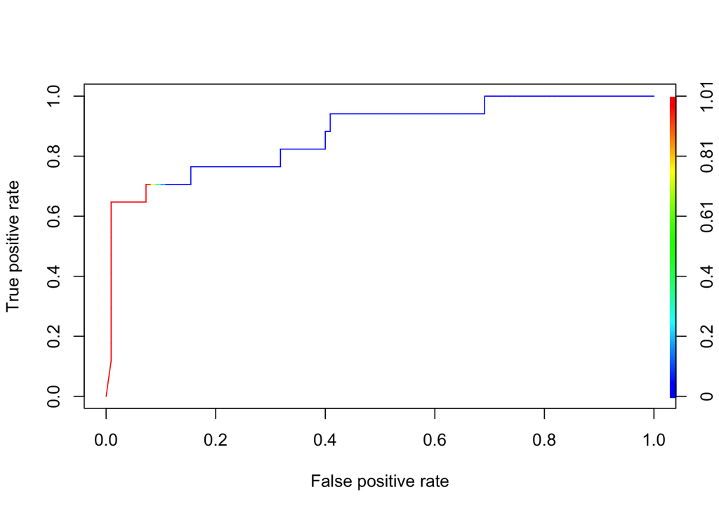

```r
roc <- prediction(test_predict[,2], test_y)

# calculates the ROC curve
perf <- performance(roc,"tpr","fpr")
plot(perf,colorize=TRUE)
```

```r
# obtaining the AUC
performance(roc, measure = "auc")@y.values[[1]]
```

```
## [1] 0.8743316
```

The AUC for HER2.Final.Status is 0.8743316.